# Tutorial for spatial ordinal pattern tests

## Libraries

```julia
using StatsOrdinalPatterns, Random, Statistics, DataFrames, CairoMakie
```

## Hypothesis Testing with Spatial Ordinal Patterns

A spatial ordinal pattern (SOP) test asks whether the frequencies of rank permutations in a 2D image are consistent with a spatially i.i.d. process. For an $M \times N$ image, overlapping $2 \times 2$ windows at delays $(d_1, d_2)$ are each mapped to the permutation that describes the relative order of the four values. The resulting frequency distribution is summarised by a scalar test statistic. Under $H_0$ (spatial white noise) that distribution is uniform across all $4! = 24$ patterns.

`StatsOrdinalPatterns.jl` provides:

- **Computing the statistic**
  - `stat_sop()` — computes the chosen test statistic from the observed pattern frequencies.
- **Asymptotic inference**
  - `test_sop()` — compares the statistic to an analytical critical value. Supports all image sizes.
- **Bootstrap inference**
  - `bootstrap_sop()` — generates the empirical null distribution by 2D resampling.
  - `test_sop_bootstrap()` — combines statistic computation and bootstrap inference in one call.

## Key functions

- **`stat_sop(data, d1, d2; chart_choice, refinement=OrdinaryType())`**
  - Returns `[test_statistic, pattern_frequencies]`.
  - `data`: the 2D image (`Matrix`). `d1`: row delay. `d2`: column delay.
  - `chart_choice`: one of `TauTilde()`, `TauHat()`, `KappaTilde()`, `KappaHat()`, `DistanceToWhiteNoise()`, [`Shannon(base=exp(1))`](https://juliadynamics.github.io/ComplexityMeasures.jl/stable/information_measures/#ComplexityMeasures.Shannon), [`ShannonExtropy(base=exp(1))`](https://juliadynamics.github.io/ComplexityMeasures.jl/stable/information_measures/#ComplexityMeasures.ShannonExtropy).
  - `refinement`: `OrdinaryType()` for classical types, or `RotationType()`, `DirectionType()`, `DiagonalType()`.
- **`test_sop(data, d1, d2; chart_choice, refinement=OrdinaryType(), alpha=0.05)`**
  - Returns an `SOPTestResult` with the test statistic, critical value, p-value, and reject decision.
  - Critical value, p-value, and rejection direction are chosen automatically from `chart_choice`.
  - `alpha`: significance level.
- **`bootstrap_sop(data, n_boot, d1, d2; chart_choice, refinement=OrdinaryType(), block_size=1)`**
  - Returns a length-`n_boot` vector of resampled statistics under $H_0$.
  - `block_size > 1`: 2D block bootstrap that preserves spatial structure.
- **`test_sop_bootstrap(data, n_boot, d1, d2; chart_choice, refinement=OrdinaryType(), alpha=0.05, block_size=1)`**
  - Returns an `SOPTestResultBoot` struct with the bootstrap critical value, p-value, and reject decision.
  - For Tau/Kappa charts: two-sided bootstrap using the raw statistic.
  - For entropy charts: the bootstrap null distribution is built on the same standardised scale used internally by `test_sop`, so the bootstrap and asymptotic critical values are directly comparable.

## Available chart statistics

Seven chart statistics are available. They differ in what they measure and the direction of the rejection region.

[output not shown]

- The four Tau/Kappa statistics use a **two-sided** test (signed deviation from zero).
- The three entropy statistics undergo an internal standardisation that converts them to **upper-tail** tests — both `test_sop` and `test_sop_bootstrap` apply this standardisation consistently, so their critical values sit on the same scale and can be compared directly.
- The asymptotic critical values and limiting distributions are derived in Weiß (2022).
- [`Shannon`](https://juliadynamics.github.io/ComplexityMeasures.jl/stable/information_measures/#ComplexityMeasures.Shannon) and [`ShannonExtropy`](https://juliadynamics.github.io/ComplexityMeasures.jl/stable/information_measures/#ComplexityMeasures.ShannonExtropy) use base 2 by default, while the papers use the natural logarithm. The rescaled statistic, the p-value and the test decision do not depend on the base. See Logarithm base for details.

## Setup

```julia
Random.seed!(42)
M, N = 20, 20   # image dimensions
d1, d2 = 1, 1     # row and column delays
```

```
(1, 1)
```

## Example data

```julia
data_iid = randn(M, N)   # spatial white noise — H₀ is true

φ = 0.4
data_sar = zeros(M, N)
data_sar[1, :] .= randn(N);
data_sar[:, 1] .= randn(M);
for i in 2:M, j in 2:N
    data_sar[i, j] = φ * (data_sar[i-1, j] + data_sar[i, j-1]) / 2 + randn()
end   # SAR-type process — H₀ is false
```

## Asymptotic testing: `test_sop()`

### Two-sided — TauTilde

```julia
test_sop(data_iid, d1, d2; chart_choice=TauTilde())
```

```
SOPTestResult
  Chart:            TauTilde()
  Statistic:        -0.0148
  ─────────────────────────────
  Asymptotic test
    Critical value: 0.053
    p-value:        0.5851
    Reject H₀:      false
```

```julia
test_sop(data_sar, d1, d2; chart_choice=TauTilde())
```

```
SOPTestResult
  Chart:            TauTilde()
  Statistic:        -0.1034
  ─────────────────────────────
  Asymptotic test
    Critical value: 0.053
    p-value:        0.0001
    Reject H₀:      true
```

### Upper-tail — DistanceToWhiteNoise

```julia
test_sop(data_iid, d1, d2; chart_choice=DistanceToWhiteNoise())
```

```
SOPTestResult
  Chart:            DistanceToWhiteNoise()
  Statistic:        0.0059
  ─────────────────────────────
  Asymptotic test
    Critical value: 0.0063
    p-value:        0.0607
    Reject H₀:      false
```

```julia
test_sop(data_sar, d1, d2; chart_choice=DistanceToWhiteNoise())
```

```
SOPTestResult
  Chart:            DistanceToWhiteNoise()
  Statistic:        0.016
  ─────────────────────────────
  Asymptotic test
    Critical value: 0.0063
    p-value:        0.0005
    Reject H₀:      true
```

### Upper-tail — Shannon entropy

```julia
test_sop(data_iid, d1, d2; chart_choice=Shannon(base=exp(1)))
```

```
SOPTestResult
  Chart:            Shannon(base = 2.718281828459045)
  Statistic:        0.0058
  ─────────────────────────────
  Asymptotic test
    Critical value: 0.0063
    p-value:        0.0636
    Reject H₀:      false
```

```julia
test_sop(data_sar, d1, d2; chart_choice=Shannon(base=exp(1)))
```

```
SOPTestResult
  Chart:            Shannon(base = 2.718281828459045)
  Statistic:        0.0171
  ─────────────────────────────
  Asymptotic test
    Critical value: 0.0063
    p-value:        0.0003
    Reject H₀:      true
```

The white-noise image is not rejected; the SAR image is. The critical value depends on the image dimensions `M`, `N`, the delays `d1`, `d2`, and `alpha` — not on the data.

## Bootstrap testing: `test_sop_bootstrap()`

`test_sop_bootstrap()` generates the empirical null distribution via 2D resampling of the observed image and computes the bootstrap critical value and p-value in the correct direction.

```julia
Random.seed!(42)
res_boot = test_sop_bootstrap(data_sar, 2_000, d1, d2; chart_choice=TauTilde())
```

```
SOPTestResultBoot
  Chart:            TauTilde()
  Statistic:        -0.1034
  ─────────────────────────────
  Bootstrap  (n_boot = 2000)
    Critical value: 0.0536
    p-value:        0.0
    Reject H₀:      true
```

The bootstrap critical value agrees closely with the asymptotic one shown above.

With `CairoMakie` loaded, `plot` shows the resampled statistics stored in `res_boot.boot_dist` as a histogram, together with the two sided rejection region, the critical values and the observed statistic. See the plotting tutorial for the options.

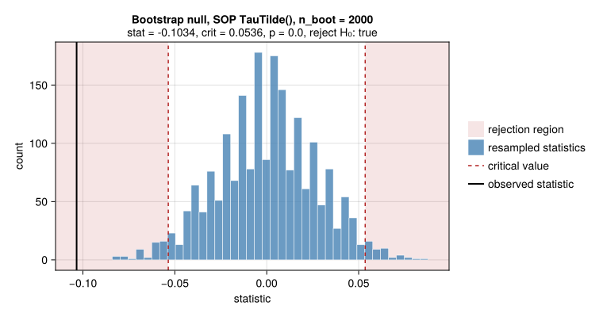

```julia
plot(res_boot)
```

## Full comparison: asymptotic vs. bootstrap

```julia
Random.seed!(42)
chart_list = [
    ("TauTilde (τ̃)", TauTilde(), "two-sided"),
    ("TauHat (τ̂)", TauHat(), "two-sided"),
    ("KappaTilde (κ̃)", KappaTilde(), "two-sided"),
    ("KappaHat (κ̂)", KappaHat(), "two-sided"),
    ("DistanceToWhiteNoise (Δ)", DistanceToWhiteNoise(), "upper-tail"),
    ("Shannon entropy (H)", Shannon(base=exp(1)), "upper-tail"),
    ("Shannon extropy (Hex)", ShannonExtropy(base=exp(1)), "upper-tail"),
]
asymp_res = [test_sop(data_sar, d1, d2; chart_choice=c) for (_, c, _) in chart_list]
boot_res = [test_sop_bootstrap(data_sar, 2_000, d1, d2; chart_choice=c) for (_, c, _) in chart_list]
```

```julia
DataFrame(
    Statistic=[t[1] for t in chart_list],
    Direction=[t[3] for t in chart_list],
    asymp_crit=round.([r.asymp_crit for r in asymp_res], digits=3),
    asymp_pval=round.([r.asymp_pval for r in asymp_res], digits=3),
    boot_crit=round.([r.boot_crit for r in boot_res], digits=3),
    boot_pval=round.([r.boot_pval for r in boot_res], digits=3),
    reject=[r.asymp_reject for r in asymp_res],
)
```

7×7 DataFrame

| Row | Statistic String | Direction String | asymp_crit Float64 | asymp_pval Float64 | boot_crit Float64 | boot_pval Float64 | reject Bool |
| --- | --- | --- | --- | --- | --- | --- | --- |
| 1 | TauTilde (τ̃) | two-sided | 0.053 | 0.0 | 0.054 | 0.0 | true |
| 2 | TauHat (τ̂) | two-sided | 0.051 | 0.046 | 0.052 | 0.055 | true |
| 3 | KappaTilde (κ̃) | two-sided | 0.087 | 1.0 | 0.086 | 1.0 | false |
| 4 | KappaHat (κ̂) | two-sided | 0.091 | 0.001 | 0.089 | 0.001 | true |
| 5 | DistanceToWhiteNoise (Δ) | upper-tail | 0.006 | 0.0 | 0.006 | 0.0 | true |
| 6 | Shannon entropy (H) | upper-tail | 0.006 | 0.0 | 0.007 | 0.001 | true |
| 7 | Shannon extropy (Hex) | upper-tail | 0.006 | 0.001 | 0.006 | 0.0 | true |

## References

Weiß, Christian H. 2022. “Non-Parametric Tests for Serial Dependence in Time Series Based on Asymptotic Implementations of Ordinal-Pattern Statistics.” *Chaos: An Interdisciplinary Journal of Nonlinear Science* 32 (9). https://pubs.aip.org/aip/cha/article-abstract/32/9/093107/2835852/Non-parametric-tests-for-serial-dependence-in-time?redirectedFrom=fulltext.